# Reproducible Research: Peer Assessment 1

Research reproduced by: Zhengming Song at Sun May 18 19:09:11 2014

## Loading and preprocessing the data

```r
rawdata = read.table("activity.csv", sep = ",", header = T)
data = rawdata[!is.na(rawdata$steps), ]
dates = levels(data$date)
cleandata = data.frame(date = as.Date(dates), totsteps = rep(0, length(dates)))
for (i in 1:length(dates)) {
    cleandata$totsteps[i] = sum(data$steps[data$date == dates[i]])
}
head(cleandata)
```

```
##         date totsteps
## 1 2012-10-01        0
## 2 2012-10-02      126
## 3 2012-10-03    11352
## 4 2012-10-04    12116
## 5 2012-10-05    13294
## 6 2012-10-06    15420
```

## What is mean total number of steps taken per day?

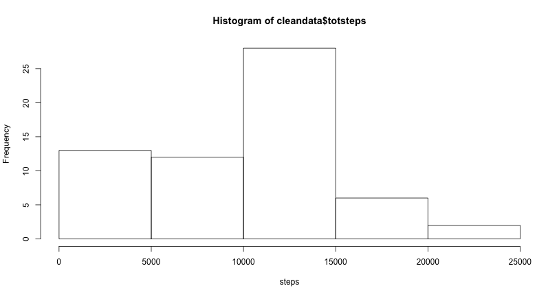

```r
hist(cleandata$totsteps, xlab = "steps")
```

```r
avg = mean(cleandata$totsteps)
med = median(cleandata$totsteps)
```

Mean of total number of steps taken per day is 9354.2295  
Median of total number of steps taken per day is 1.0395 × 10<sup>4</sup>

## What is the average daily activity pattern?

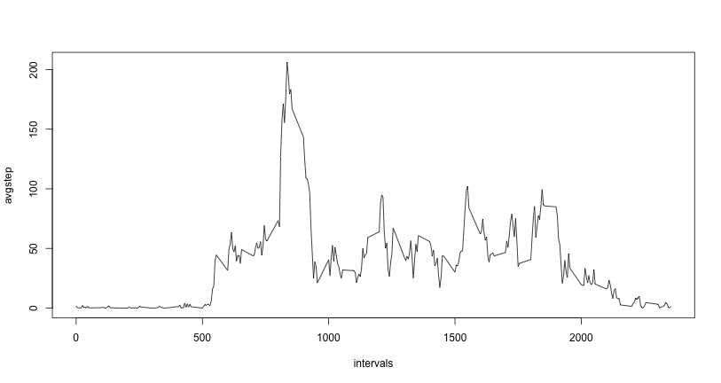

```r
intervals = levels(factor(data$interval))
avgstep = rep(0, length(intervals))
for (i in 1:length(intervals)) {
    avgstep[i] = mean(data$steps[data$interval == intervals[i]])
}

plot(intervals, avgstep, type = "l")
```

Determine which interval contains the maximum number of steps on average across all the days

```r
ind = intervals[which(avgstep == max(avgstep))]
```

It turns out interval 835 contains maximum number of steps on average across all the days

## Imputing missing values

```r
num_na = sum(is.na(rawdata$steps))
```

- There are 2304 rows with NAs
- Let's fill the missing values by the average value of that 5-minute interval
- Let's call the new dataset as newdata

```r
newdata = rawdata
ind = which(is.na(newdata), arr.ind = TRUE)
for (i in 1:dim(ind)[1]) {
    newdata$steps[ind[i, 1]] = avgstep[intervals == newdata$interval[ind[i,
        1]]]
}
head(newdata)
```

```
##     steps       date interval
## 1 1.71698 2012-10-01        0
## 2 0.33962 2012-10-01        5
## 3 0.13208 2012-10-01       10
## 4 0.15094 2012-10-01       15
## 5 0.07547 2012-10-01       20
## 6 2.09434 2012-10-01       25
```

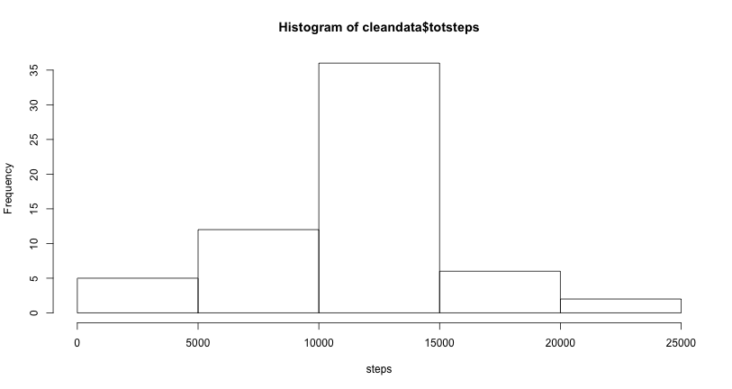

```r
dates = levels(newdata$date)
cleandata = data.frame(date = as.Date(dates), totsteps = rep(0, length(dates)))
for (i in 1:length(dates)) {
    cleandata$totsteps[i] = sum(newdata$steps[newdata$date == dates[i]])
}
hist(cleandata$totsteps, xlab = "steps")
```

```r
avg = mean(cleandata$totsteps)
med = median(cleandata$totsteps)
```

- The mean value is 1.0766 × 10<sup>4</sup>, and the median is 1.0766 × 10<sup>4</sup> now. we can observe that the histogram and values are different as those from first part. Filling the missing data fix the estimation bias (the mean changed)

## Are there differences in activity patterns between weekdays and weekends?

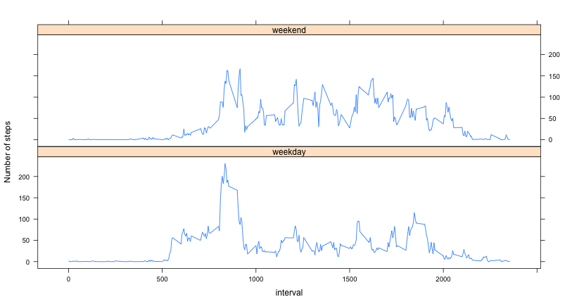

```r
# Sepreate newdata to two sub dataset according to weekday or weekend
dates = as.Date(newdata$date)
weekendsind = which(weekdays(dates) == "Sunday" | weekdays(dates) == "Saturday",
    arr.ind = TRUE)
weekdaysind = which(weekdays(dates) == "Monday" | weekdays(dates) == "Tuesday" |
    weekdays(dates) == "Wednesday" | weekdays(dates) == "Thursday" | weekdays(dates) ==
    "Friday", arr.ind = TRUE)
weekdaydata = newdata[weekdaysind, ]
weekenddata = newdata[weekendsind, ]

# construct new dataset, weekdata, to store the data for plotting
intervals = levels(factor(weekenddata$interval))
avgstep = rep(0, length(intervals))
for (i in 1:length(intervals)) {
    avgstep[i] = mean(weekenddata$steps[weekenddata$interval == intervals[i]])
}

weekdata = data.frame(interval = as.numeric(intervals), steps = avgstep)

intervals = levels(factor(weekdaydata$interval))
avgstep = rep(0, length(intervals))
for (i in 1:length(intervals)) {
    avgstep[i] = mean(weekdaydata$steps[weekdaydata$interval == intervals[i]])
}

weekdata = rbind(data.frame(interval = as.numeric(intervals), steps = avgstep),
    weekdata)

# plot for comparison
library(lattice)
attach(weekdata)
weekday.f = gl(2, length(interval)/2, labels = c("weekday", "weekend"))
xyplot(steps ~ interval | weekday.f, auto.key = TRUE, layout = c(1, 2), type = "l",
    ylab = "Number of steps")
```

- The new factor variable is weekday.f
- From the panel plot above, we can observe that the behavior is different from weekend to weekday.